# Pràctica 2

Joan Ribera i Jordi Fuster

Gener 2020

# 1. Descripció del dataset. Perquè és important i quina pregunta/problema pretén respondre?

Com ja es va comentar a la pràctica 1, en els darrers anys a Andorra s’ha experimentat un creixement molt important dels preus dels pisos de lloguer degut a una disminució de l’oferta i un increment de la demanda. Aquesta situació ha comportat que el preu de l’habitatge s’hagi convertit en la primera preocupació pel 41,1% de la població, segons l’enquesta de l’Observatori del CRES del primer semestre del 2018.

Com ja es va explicar en la primera pràctica, aquesta situació no es veu reflectida a les dades que publica el Departament d’Estadística d’Andorra segons les dades de l’Enquesta de Pressupostos Familiars, ja que els contractes de lloguer antics disminueixen la mitjana dels preus pagats.

Amb les dades obtingudes del portal d’anuncis www.buscocasa.ad, l’objectiu serà analitzar el preu mitjà i el preu mitjà per metre quadrat dels habitatges que s’oferten per donar informació complementaria a la que ofereix l’estadística oficial. Així, no obtindrem el que es paga de mitjana, sinó el que costaria de mitjana llogar un habitatge.

També interessarà comparar els preus i les característiques dels habitatges de les dues parròquies centrals: Andorra la Vella i Escaldes.

El dataset conté:

- descripcio (Caràcter): Descripció completa de l’anunci.
- tipusHabitatge (Caràcter): Tipologia d’habitatge (pis,casa, xalet, etc.)
- poble (Caràcter): Poble on es troba l’habitatge
- parroquia (Caràcter): Parròquia on es troba l’habitatge
- dataAnunci (Data): Data de publicació de l’anunci
- m2 (Numèric): Metres quadrats que té el pis
- numHabitacions (Numèric): Nombre d’habitacions de l’habitatge
- tipusOferta (Caràcter): Tipus d’oferta de l’anunci: lloguer, propietat
- numVisites (Numèric): Nombre de visites que ha rebut l’anunci
- preu (Numèric): Preu al que s’anuncia l’habitatge.

# 2. Integració i selecció de les dades d’interès a analitzar.

Les dades que utilitzarem seran: - Parroquia/Poble: per detectar diferències entre preus de diferents parròquies - m2: per calcular posteriorment el preu per metre quadrat (desprès d’imputar) - nombre d’habitacions: per calcular preus en funció de les habitacions - Preu: per calcular el preu i el preu per metre quadrat.

```r
#Carreguem les dades
library(readr)
anuncis_habitatges_andorra <- read_delim("C:/Users/jordi/OneDrive/Desktop/anuncis_habitatges_andorra.csv",
    "\t", escape_double = FALSE, trim_ws = TRUE)

#anuncis_habitatges_andorra<- read.csv(file="~/Desktop/anuncis_habitatges_andorra.csv",
#                                     header=TRUE, sep="\t")


head(anuncis_habitatges_andorra)
```

```
## # A tibble: 6 x 11
##      X1 descripcio tipusHabitatge poble parroquia dataAnunci    m2
##   <dbl> <chr>      <chr>          <chr> <chr>     <chr>      <dbl>
## 1     0 Lloguer -~ Pis            ando~ andorra ~ 08/11/2019    NA
## 2     1 Lloguer 1~ NaN            ando~ andorra ~ 06/11/2019   105
## 3     2 Lloguer 1~ Pis            ando~ andorra ~ 06/11/2019   140
## 4     3 Lloguer 9~ NaN            ando~ andorra ~ 05/11/2019    90
## 5     4 Lloguer 9~ Pis            erts  andorra ~ 04/11/2019    95
## 6     5 Lloguer 1~ Pis            ando~ andorra ~ 31/10/2019   110
## # ... with 4 more variables: numHabitacions <dbl>, tipusOferta <chr>,
## #   numVisites <dbl>, preu <dbl>
```

# 3. Neteja de les dades.

## 3.1. Les dades contenen zeros o elements buits? Com gestionaries aquests casos?

```r
summary(anuncis_habitatges_andorra$m2)
```

```
##    Min. 1st Qu.  Median    Mean 3rd Qu.    Max.    NA's
##    12.0    88.0   100.0   122.6   130.0   700.0      10
```

```r
summary(anuncis_habitatges_andorra$numHabitacions)
```

```
##    Min. 1st Qu.  Median    Mean 3rd Qu.    Max.
##   1.000   2.000   3.000   2.653   3.000   4.000
```

```r
summary(anuncis_habitatges_andorra$preu)
```

```
##    Min. 1st Qu.  Median    Mean 3rd Qu.    Max.
##     400     985    1150    7588    1375  483000
```

```r
#La variable m2 presenta missings que els tractarem imputant a posteriori, perquè ens serviran per calcular els preus per m2.

#imputar m2 per la mitjana. Utilitzarem el paquet Hmisc per a fer-ho.
anuncis_habitatges_andorra1<-anuncis_habitatges_andorra
library(Hmisc)
anuncis_habitatges_andorra1$m2 <- with(anuncis_habitatges_andorra1, impute(m2, mean))
summary(anuncis_habitatges_andorra1$m2)
```

```
##
##  10 values imputed to 122.6349
```

```
##    Min. 1st Qu.  Median    Mean 3rd Qu.    Max.
##    12.0    88.0   100.0   122.6   130.0   700.0
```

```r
anuncis_habitatges_andorra1$m2<-as.numeric(anuncis_habitatges_andorra1$m2)
```

## 3.2. Identificació i tractament de valors extrems.

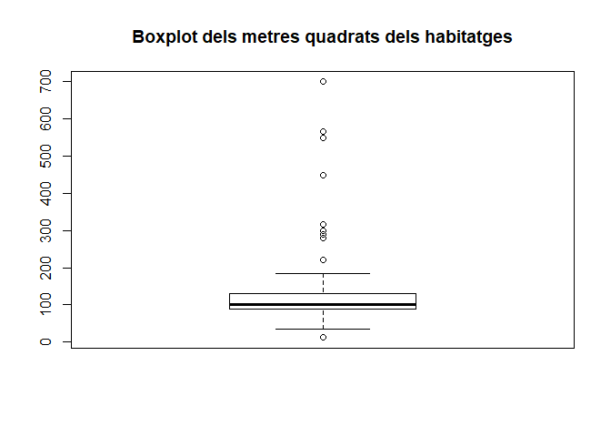

```r
boxplot(anuncis_habitatges_andorra1$m2, main="Boxplot dels metres quadrats dels habitatges")
```

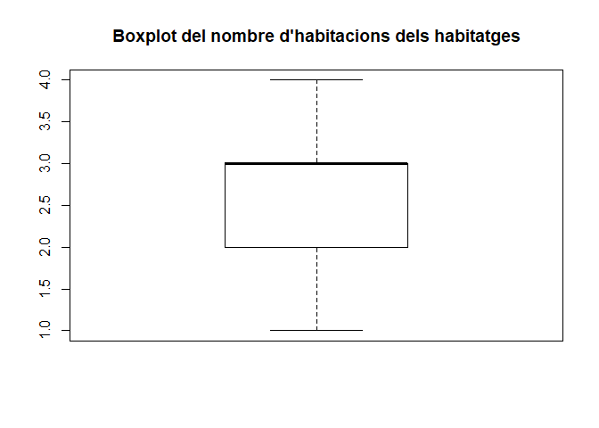

```r
boxplot(anuncis_habitatges_andorra1$numHabitacions, main="Boxplot del nombre d'habitacions dels habitatges")
```

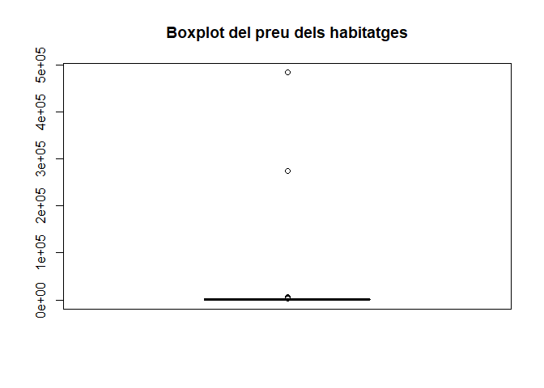

```r
boxplot(anuncis_habitatges_andorra1$preu, main="Boxplot del preu dels habitatges")
```

```r
#La variable m2 presenta uns valors extrems, però que poden ser reals. (habitatges amb molts metres quadrats). Els deixarem a la mostra.
#La variable m2 presenta valors molt petits: 12 m2. Revisant la taula, observem que a la descripció ho defineix com a despatxos de 12m2. Per tant, els traiem de la mostra.
anuncis_habitatges_andorra2<- subset(anuncis_habitatges_andorra1, anuncis_habitatges_andorra1$m2>12 | is.na(anuncis_habitatges_andorra$m2)>0)


#La variable numHabitacions no presenta cap valor outlier.

#La variable preu presenta uns valors extrems compatibles amb un error. Concretament, el programa havia extret els valors per als habitatges de lloguer, però aquests valors tant elevats ens fan pensar que són habitatges en venda, que s'han posat com a lloguer.

# Eliminarem aquells anuncis que estan anunciats com lloguer, però realment són per venda.
row.names(anuncis_habitatges_andorra2) <- 1:nrow(anuncis_habitatges_andorra2)
outlier_values <- boxplot.stats(anuncis_habitatges_andorra2$preu, coef=12)$out  #

# Els outliers trobats són:
boxplot.stats(anuncis_habitatges_andorra2$preu, coef=12)$out
```

```
## [1] 274000 483000 483000
```

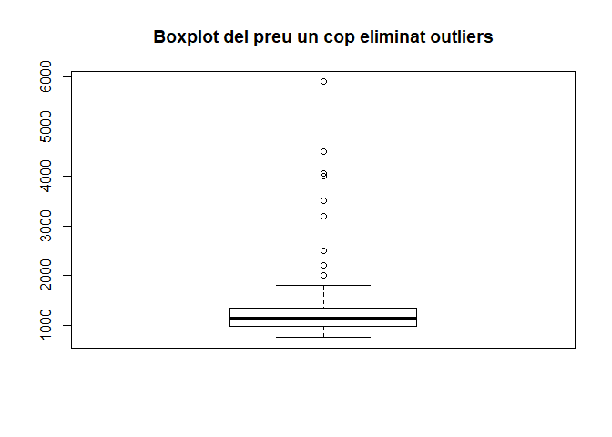

```r
anuncis_habitatges_andorra2<-anuncis_habitatges_andorra2[!(anuncis_habitatges_andorra2$preu) %in% outlier_values,]


# Treiem els espais al final del string de parròquia.
anuncis_habitatges_andorra2$parroquia<-trimws(anuncis_habitatges_andorra2$parroquia, "b")

boxplot(anuncis_habitatges_andorra2$preu, main="Boxplot del preu un cop eliminat outliers")
```

```r
#Creem la variable de preu per metre quadrat.
anuncis_habitatges_andorra2$pm2<-anuncis_habitatges_andorra2$preu/anuncis_habitatges_andorra2$m2
```

# 4. Anàlisi de les dades.

## 4.1. Selecció dels grups de dades que es volen analitzar/comparar (planificació dels anàlisis a aplicar).

```r
# 1. Farem un anàlisis comparant el preu i el preu per metre quadrat en les dues parròquies més grans d'andorra: Escaldes-Engordany i Andorra la Vella.
parroquies_centrals<-subset(anuncis_habitatges_andorra2, parroquia != "la massana")

# 2. Farem un anàlisi de correlacions entre les diferènts variables estudiades preu, preum2 i m2, així com d'habitacions dels habitatges

# 3. També farem un model per predir el preu dels habitatges en funció dels m2.

# 4. Finalment, farem un anàlisis de les diferències que hi pot haver entre parròquies.
```

## 4.2. Comprovació de la normalitat i homogeneïtat de la variància.

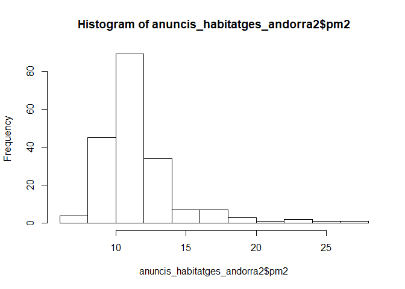

```r
# Realitzarem un histograma de les dades (preu, preum2 i m2), per a veure la distribució de les dades
hist(anuncis_habitatges_andorra2$pm2)
```

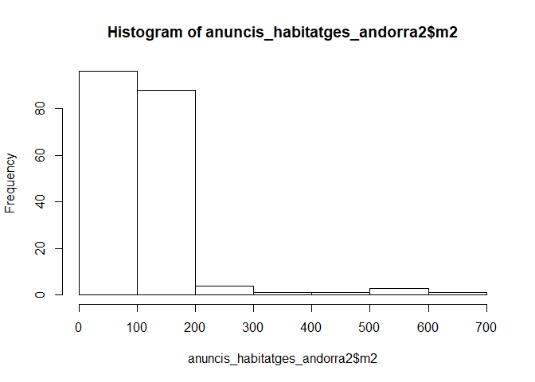

```r
hist(anuncis_habitatges_andorra2$m2)
```

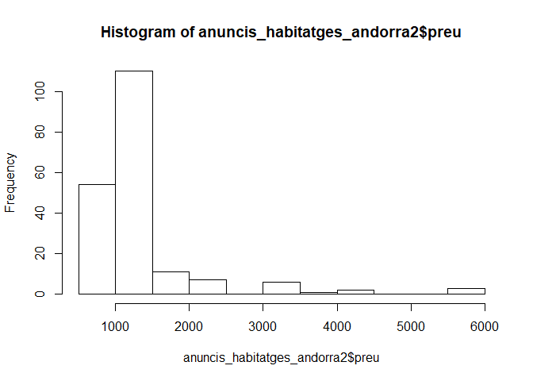

```r
hist(anuncis_habitatges_andorra2$preu)
```

```r
# Realitzarem un test de normalitat
shapiro.test(anuncis_habitatges_andorra2$pm2)
```

```
##
##  Shapiro-Wilk normality test
##
## data:  anuncis_habitatges_andorra2$pm2
## W = 0.8108, p-value = 1.342e-14
```

```r
shapiro.test(anuncis_habitatges_andorra2$m2)
```

```
##
##  Shapiro-Wilk normality test
##
## data:  anuncis_habitatges_andorra2$m2
## W = 0.51156, p-value < 2.2e-16
```

```r
shapiro.test(anuncis_habitatges_andorra2$preu)
```

```
##
##  Shapiro-Wilk normality test
##
## data:  anuncis_habitatges_andorra2$preu
## W = 0.5513, p-value < 2.2e-16
```

```r
# Les variables tenen un pvalor inferior a 0.05 i per tant no segueixen una distribució normal.

# A continuació farem un test de homogenietat de variances, per a descubrir si hi ha diferències entre les varianciès del preu, preum2 i m2 de andorra la vella i escaldes.
var.test(pm2~parroquia, data = parroquies_centrals)
```

```
##
##  F test to compare two variances
##
## data:  pm2 by parroquia
## F = 0.6413, num df = 111, denom df = 77, p-value = 0.03196
## alternative hypothesis: true ratio of variances is not equal to 1
## 95 percent confidence interval:
##  0.4207055 0.9623811
## sample estimates:
## ratio of variances
##          0.6413025
```

```r
var.test(m2~parroquia, data = parroquies_centrals)
```

```
##
##  F test to compare two variances
##
## data:  m2 by parroquia
## F = 11.673, num df = 111, denom df = 77, p-value < 2.2e-16
## alternative hypothesis: true ratio of variances is not equal to 1
## 95 percent confidence interval:
##   7.65784 17.51762
## sample estimates:
## ratio of variances
##           11.67323
```

```r
var.test(preu~parroquia, data = parroquies_centrals)
```

```
##
##  F test to compare two variances
##
## data:  preu by parroquia
## F = 2.7062, num df = 111, denom df = 77, p-value = 6.698e-06
## alternative hypothesis: true ratio of variances is not equal to 1
## 95 percent confidence interval:
##  1.775302 4.061077
## sample estimates:
## ratio of variances
##           2.706182
```

```r
# Trobem que hi ha diferències de variancies entre les dues parròquies
```